# Diamonds EDA

## carat frequency

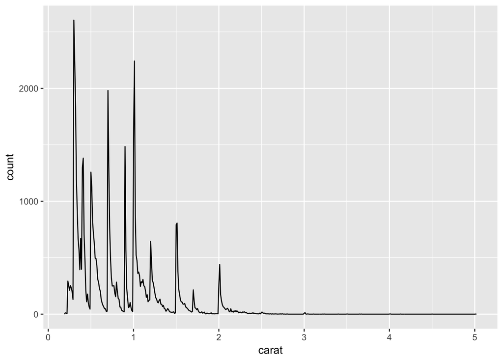

```r
ggplot(data=diamonds,aes(x=carat))+
  geom_freqpoly(binwidth=.01)
```

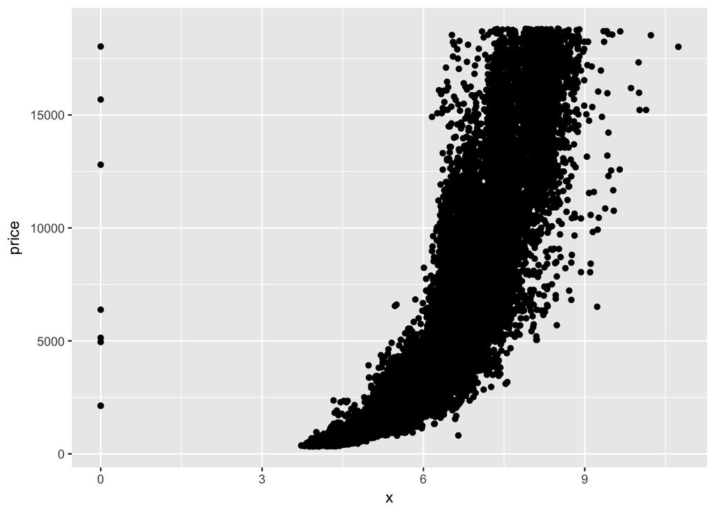

```r
ggplot(data=diamonds,aes(x=x,y=price))+
         geom_point()
```

What is going on? there is some exponential trend

```r
with(diamonds,cor.test(x,price))
```

```
##
##  Pearson's product-moment correlation
##
## data:  x and price
## t = 440.16, df = 53938, p-value < 2.2e-16
## alternative hypothesis: true correlation is not equal to 0
## 95 percent confidence interval:
##  0.8825835 0.8862594
## sample estimates:
##       cor
## 0.8844352
```

```r
with(diamonds,cor.test(y,price))
```

```
##
##  Pearson's product-moment correlation
##
## data:  y and price
## t = 401.14, df = 53938, p-value < 2.2e-16
## alternative hypothesis: true correlation is not equal to 0
## 95 percent confidence interval:
##  0.8632867 0.8675241
## sample estimates:
##       cor
## 0.8654209
```

```r
with(diamonds,cor.test(z,price))
```

```
##
##  Pearson's product-moment correlation
##
## data:  z and price
## t = 393.6, df = 53938, p-value < 2.2e-16
## alternative hypothesis: true correlation is not equal to 0
## 95 percent confidence interval:
##  0.8590541 0.8634131
## sample estimates:
##       cor
## 0.8612494
```

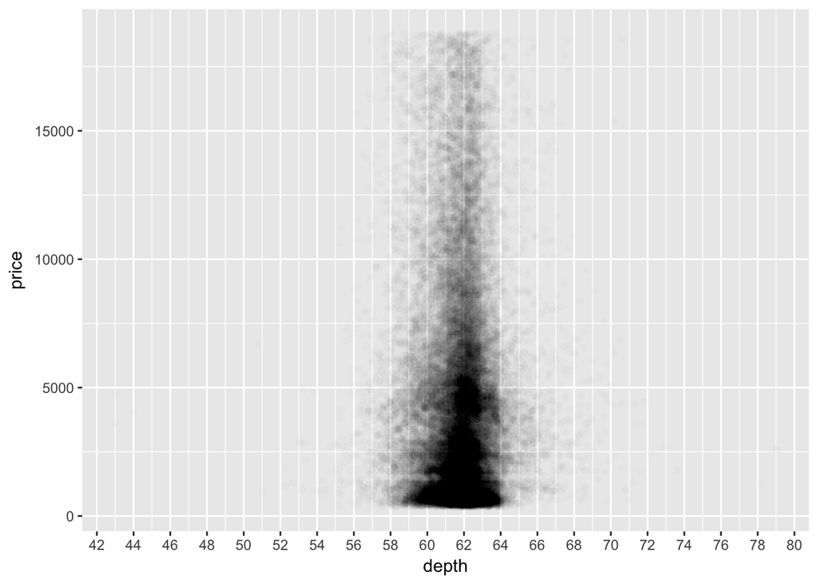

```r
ggplot(data=diamonds,aes(x=depth,y=price))+
  geom_point(alpha=1/100)+
  scale_x_continuous(breaks=seq(2,80,2))
```

typical depth range is between 58 and 64.

```r
with(diamonds,cor.test(depth,price))
```

```
##
##  Pearson's product-moment correlation
##
## data:  depth and price
## t = -2.473, df = 53938, p-value = 0.0134
## alternative hypothesis: true correlation is not equal to 0
## 95 percent confidence interval:
##  -0.019084756 -0.002208537
## sample estimates:
##        cor
## -0.0106474
```

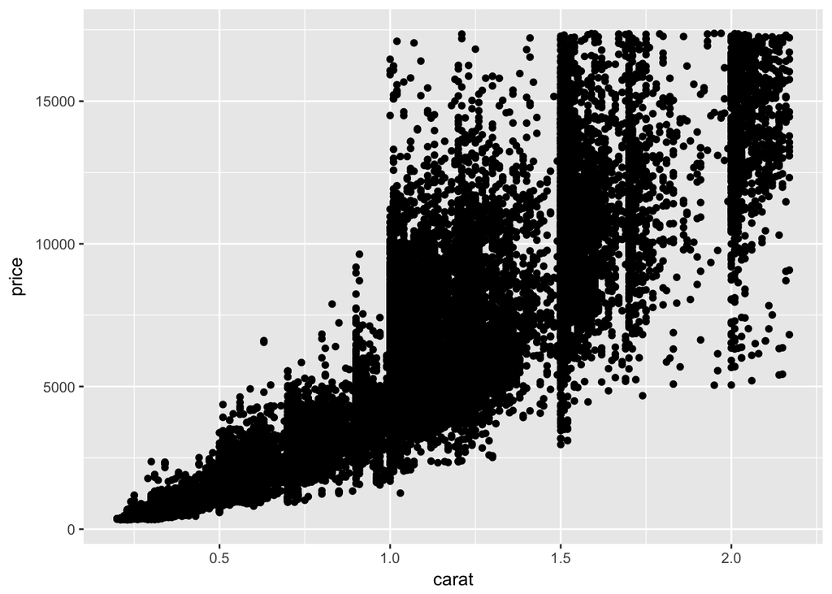

```r
ggplot(data=subset(diamonds,price<quantile(price,.99) & carat<quantile(carat,.99)),
       aes(x=carat,y=price))+
  geom_point()
```

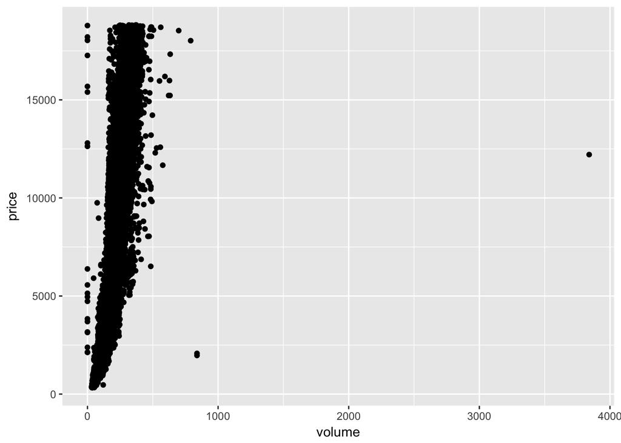

```r
diamonds%>%
  mutate(volume=x*y*z)->diamonds
ggplot(data=diamonds,aes(x=volume,y=price))+
  geom_point()
```

How many diamonds have 0 volume??

```r
sum(diamonds$volume==0)
```

```
## [1] 20
```

## what is the correlation of price and volume, excluding diamonds with volume=0 or >=800

```r
with(subset(diamonds,volume>0 & volume<=800),cor.test(price,volume))
```

```
##
##  Pearson's product-moment correlation
##
## data:  price and volume
## t = 559.19, df = 53915, p-value < 2.2e-16
## alternative hypothesis: true correlation is not equal to 0
## 95 percent confidence interval:
##  0.9222944 0.9247772
## sample estimates:
##       cor
## 0.9235455
```

## price vs volume

We encourage you to think about this next question and to post your thoughts in the discussion section.

Do you think this would be a useful model to estimate the price of diamonds? Why or why not?

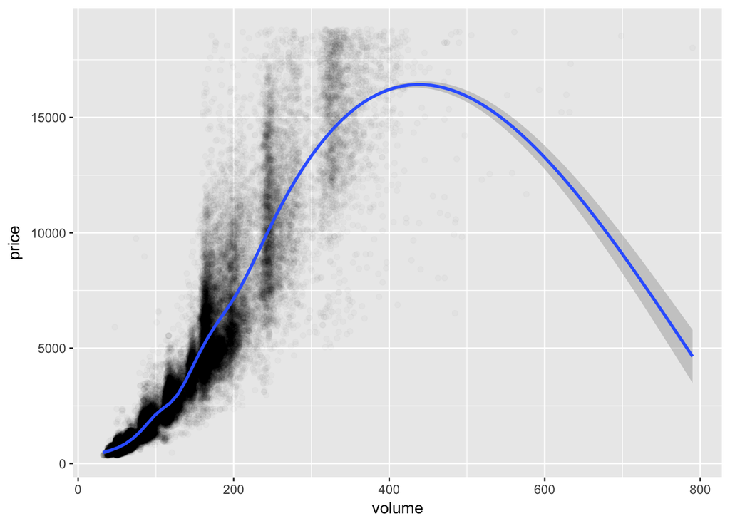

```r
ggplot(data=subset(diamonds,volume>0 & volume<=800),
       aes(x=volume,y=price))+
  geom_point(alpha=1/50)+
  geom_smooth()
```

This does not seem like a great fit because it shows that at some point, diamonds get cheaper per volume, which is very false.

Use the function dplyr package to create a new data frame containing info on diamonds by clarity.

Name the data frame diamondsByClarity

```r
diamondsByClarity<-diamonds%>%
  group_by(clarity)%>%
  summarise(mean_price=mean(price),
            median_price=median(price),
            min_price=min(price),
            max_price=max(price),
            n=n())
head(diamondsByClarity)
```

```
## # A tibble: 6 x 6
##   clarity mean_price median_price min_price max_price     n
##   <ord>        <dbl>        <dbl>     <dbl>     <dbl> <int>
## 1 I1            3924         3344       345     18531   741
## 2 SI2           5063         4072       326     18804  9194
## 3 SI1           3996         2822       326     18818 13065
## 4 VS2           3925         2054       334     18823 12258
## 5 VS1           3839         2005       327     18795  8171
## 6 VVS2          3284         1311       336     18768  5066
```

```r
library(gridExtra)
diamonds_by_clarity <- group_by(diamonds, clarity)
diamonds_mp_by_clarity <- summarise(diamonds_by_clarity, mean_price = mean(price))

diamonds_by_color <- group_by(diamonds, color)
diamonds_mp_by_color <- summarise(diamonds_by_color, mean_price = mean(price))

diamonds_mp_by_clarity
```

```
## # A tibble: 8 x 2
##   clarity mean_price
##   <ord>        <dbl>
## 1 I1            3924
## 2 SI2           5063
## 3 SI1           3996
## 4 VS2           3925
## 5 VS1           3839
## 6 VVS2          3284
## 7 VVS1          2523
## 8 IF            2865
```

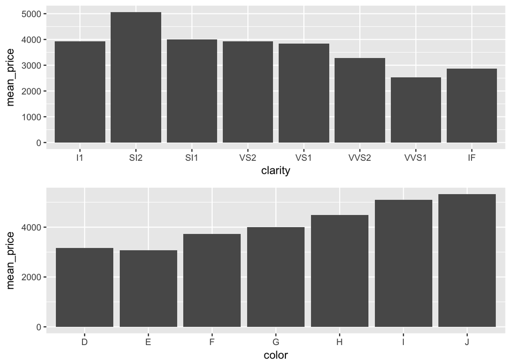

```r
dclar<-ggplot(data=diamonds_mp_by_clarity,aes(x=clarity,y=mean_price))+
  geom_col()

dcol<-ggplot(data=diamonds_mp_by_color,aes(x=color,y=mean_price))+
  geom_col()

grid.arrange(dclar,dcol,ncol=1)
```

# Multiple variables

## Create a histogram of diamond prices.

Facet the histogram by diamond color and use cut to color the histogram bars.

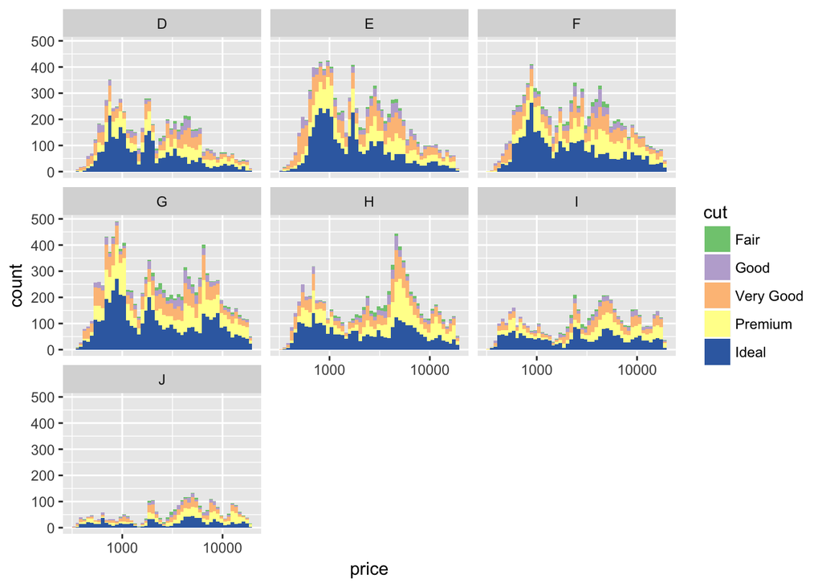

```r
ggplot(data=diamonds,aes(x=price,fill=cut))+
  geom_histogram(bins=50)+
  scale_x_log10()+
  facet_wrap(~color)+
  scale_fill_brewer(type='qual')
```

## Create a scatterplot of diamond price vs. table and color the points by the cut of the diamond.

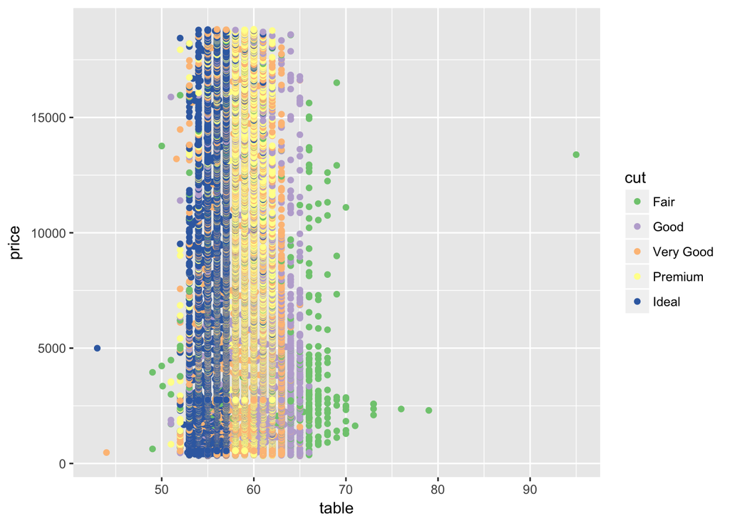

```r
ggplot(data=diamonds,aes(y=price,x=table,color=cut))+
  geom_point()+
  scale_color_brewer(type='qual')
```

What is the typical table range for diamonds of ideal cut?

53-57

What is the typical table range for diamonds of premium cut?

58-62